# varshan_lab3

```python
import numpy as np
import matplotlib.pyplot as plt
from sklearn import datasets, linear_model
from sklearn.model_selection import train_test_split
from sklearn.metrics import mean_squared_error, r2_score
```

```python
diabetes_X, diabetes_y = datasets.load_diabetes(return_X_y=True)
```

```python
X_train, X_test, y_train, y_test = train_test_split(diabetes_X[:, np.newaxis, 2], diabetes_y, test_size=0.2, random_state=42)
```

```python
regr = linear_model.LinearRegression()
regr.fit(X_train, y_train)
```

```
LinearRegression()
```

```python
y_pred = regr.predict(X_test)
```

```python
mse = mean_squared_error(y_test, y_pred)
r2 = r2_score(y_test, y_pred)
```

```python
print("Coefficients: ", regr.coef_)
print("Intercept: ", regr.intercept_)
print("Mean Squared Error (MSE): %.2f" % mse)
print("R-squared (R2): %.2f" % r2)
```

```
Coefficients:  [998.57768914]
Intercept:  152.00335421448167
Mean Squared Error (MSE): 4061.83
R-squared (R2): 0.23
```

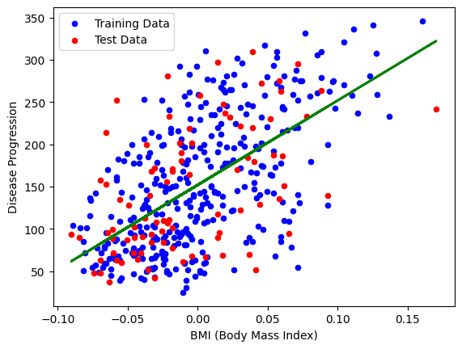

```python
# Scatter plot of training data
plt.scatter(X_train, y_train, color='blue', s=20, label='Training Data')

# Scatter plot of test data
plt.scatter(X_test, y_test, color='red', s=20, label='Test Data')

# Plot the linear regression line
plt.plot(X_test, y_pred, color='green', linewidth=2)

# Add labels and legend
plt.xlabel('BMI (Body Mass Index)')
plt.ylabel('Disease Progression')
plt.legend(loc='upper left')

# Show the plot
plt.show()
```

In our analysis of the relationship between BMI (Body Mass Index) and disease progression in diabetes patients:

The linear regression model revealed a significant positive association between BMI and disease progression, with a slope coefficient of approximately 998.58. This indicates that higher BMI values are, on average, associated with greater disease progression one year after baseline.

The model's performance metrics included a Mean Squared Error (MSE) of approximately 4061.83 and an R-squared (R2) score of 0.23. While the model explains only a moderate portion of the variance in disease progression, it provides valuable insights into the relationship.

Visualizations of the data and regression line supported the model's fit to the dataset, with the regression line capturing the general trend, though variability exists.

In conclusion, the univariate linear regression model provides a reasonable fit to the diabetes dataset, emphasizing the positive link between BMI and disease progression. Although the model's explanatory power is moderate, it offers valuable insights into the impact of BMI on disease outcomes in diabetes patients. Further research and model enhancements may uncover more detailed insights into this relationship.